# Statistical Inference Course Project

Part 1: Simulation Exercises

Omer Kara

Friday, January 15, 2016

Source code for this entire report can be found [here](https://github.com/omerkara/Coursera_Statistical-Inference).

## Overview

The exponential distribution (a.k.a. negative exponential distribution) is the probability distribution that describes the time between events in a Poisson process, i.e. a process in which events occur continuously and independently at a constant average rate.[^1] It is a special case of the gamma distribution. The exponential distribution can be simulated in R with `rexp(n, lambda)` where `lambda` such that $\lambda > 0$ is the parameter of the distribution, often called the rate parameter. The distribution is supported on the interval $[{0, \infty})$. If a random variable X has this distribution, we write $X \sim Exp(\lambda)$. Note that the mean and standard deviation of exponential distribution is $1/\lambda$. For more information about the moments of exponential distribution please see [Exponential Distribution Wiki Page](https://en.wikipedia.org/wiki/Exponential_distribution).

For this simulation exercie, $\lambda=0.2$ is given. In this simulation, we investigate the distribution of averages of 40 observations sampled from exponential distribution with $\lambda=0.2$ with 1000 simulations.

## Simulation

```r
set.seed(1)
lambda <- 0.2
obs <- 40
sim <- 1000
data <- data.frame(means = apply(matrix(rexp(sim * obs, rate = lambda), sim), 1, mean))
```

## Theoretical vs. Empirical Distribution

The central limit theorem (CLT) states that averages of sufficiently larger number of independently and identically distributed observations, each with a well-defined expected value and well-defined variance, will be asymptotically normally distributed, regardless of the underlying distribution. Therefore, following the theory, we are expecting to see our simulation data is distributed as $\overline{X} \sim \mathcal{N}(\mu,\sigma^2/n)$. More specifically, in our case the theoretical distribution is as follows $\overline{X} \sim \mathcal{N}(\lambda^{-1},\lambda^{-2}/n)$.

The following results clearly shows that our simulation coincides with the theosry very well since the moments of empirical distribution is very close to the theoretical counterparts.

```r
## Theoretical vs. Empirical mean.
mu <- c(1/lambda, mean(data$means))
mu
```

```
## [1] 5.000000 4.990025
```

```r
## Theoretical vs. Empirical variance.
var <- c(1/((lambda ^ 2)*obs), var(data$means))
var
```

```
## [1] 0.6250000 0.6177072
```

```r
## Theoretical standard deviation vs. Empirical standard error.
sd <- c(sqrt(1/((lambda ^ 2)*obs)), sd(data$means))
sd
```

```
## [1] 0.7905694 0.7859435
```

## Empirical and Theoretical Distributions

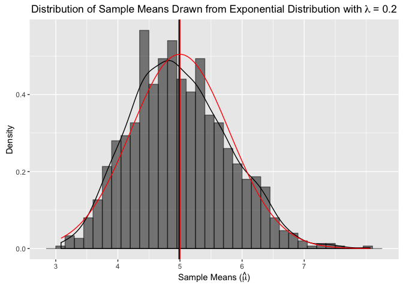

## Formal Normality Tests

```r
shapiro.test(data$means) ## Normality check with Shapiro-Wilk test.
```

```
##
##  Shapiro-Wilk normality test
##
## data:  data$means
## W = 0.99157, p-value = 1.759e-05
```

```r
ad.test(data$means) ## Normality check with Anderson-Darling test.
```

```
##
##  Anderson-Darling normality test
##
## data:  data$means
## A = 1.9229, p-value = 6.617e-05
```

[^1]: https://en.wikipedia.org/wiki/Exponential_distribution
[^2]: Veritcal lines are the respective means.